# (Lyft GoBike System Exploration)

## Preliminary Wrangling

> This document explores a dataset containing the types of users, stations and duration of rides for approximately 132,000 bikes.

```python
# import all packages and set plots to be embedded inline
import numpy as np
import pandas as pd
import matplotlib.pyplot as plt
import seaborn as sb
import datetime
import calendar
import math
from numba import njit
from matplotlib.ticker import FuncFormatter

%matplotlib inline
```

```python
#load in the dataset into a pandas dataframe, print information
bike_data = pd.read_csv('201804-fordgobike-tripdata.csv')
bike_data.info()
```

```
<class 'pandas.core.frame.DataFrame'>
RangeIndex: 131169 entries, 0 to 131168
Data columns (total 16 columns):
duration_sec               131169 non-null int64
start_time                 131169 non-null object
end_time                   131169 non-null object
start_station_id           131169 non-null int64
start_station_name         131169 non-null object
start_station_latitude     131169 non-null float64
start_station_longitude    131169 non-null float64
end_station_id             131169 non-null int64
end_station_name           131169 non-null object
end_station_latitude       131169 non-null float64
end_station_longitude      131169 non-null float64
bike_id                    131169 non-null int64
user_type                  131169 non-null object
member_birth_year          121791 non-null float64
member_gender              121827 non-null object
bike_share_for_all_trip    131169 non-null object
dtypes: float64(5), int64(4), object(7)
memory usage: 16.0+ MB
```

```python
# high-level overview of data shape and composition
print(bike_data.shape)
print(bike_data.head(5))
```

```
(131169, 16)
   duration_sec                start_time                  end_time  \
0         72393  2018-04-30 22:49:32.6180  2018-05-01 18:56:06.3010
1         81034  2018-04-30 17:46:04.9970  2018-05-01 16:16:39.2470
2         86142  2018-04-30 16:07:13.9190  2018-05-01 16:02:56.7170
3         68839  2018-04-30 17:11:57.4640  2018-05-01 12:19:16.7870
4         59091  2018-04-30 18:45:21.5560  2018-05-01 11:10:13.5410

   start_station_id                                 start_station_name  \
0                 4                        Cyril Magnin St at Ellis St
1               122                              19th St at Mission St
2                41                         Golden Gate Ave at Polk St
3               284  Yerba Buena Center for the Arts (Howard St at ...
4               196                            Grand Ave at Perkins St

```

[output cut: 27 more lines]

```python
# descriptive statistics for numeric variables
bike_data.describe()
```

|  | duration_sec | start_station_id | start_station_latitude | start_station_longitude | end_station_id | end_station_latitude | end_station_longitude | bike_id | member_birth_year |
| --- | --- | --- | --- | --- | --- | --- | --- | --- | --- |
| count | 131169.000000 | 131169.000000 | 131169.000000 | 131169.000000 | 131169.000000 | 131169.000000 | 131169.000000 | 131169.000000 | 121791.000000 |
| mean | 885.927369 | 115.930197 | 37.762504 | -122.345369 | 113.923663 | 37.762677 | -122.344650 | 2112.806044 | 1982.080901 |
| std | 2697.759807 | 95.822508 | 0.112139 | 0.130194 | 95.496324 | 0.112045 | 0.129584 | 1165.606593 | 10.497088 |
| min | 61.000000 | 3.000000 | 37.312854 | -122.444293 | 3.000000 | 37.312854 | -122.444293 | 11.000000 | 1900.000000 |
| 25% | 348.000000 | 34.000000 | 37.771058 | -122.411726 | 30.000000 | 37.771058 | -122.409851 | 1126.000000 | 1977.000000 |
| 50% | 550.000000 | 86.000000 | 37.781123 | -122.397086 | 81.000000 | 37.781270 | -122.395936 | 2183.000000 | 1984.000000 |
| 75% | 862.000000 | 182.000000 | 37.796248 | -122.278267 | 182.000000 | 37.796248 | -122.281051 | 3118.000000 | 1989.000000 |
| max | 86142.000000 | 345.000000 | 37.880222 | -121.874119 | 345.000000 | 37.880222 | -121.874119 | 4073.000000 | 2000.000000 |

### What is the structure of your dataset?

> There are 131,169 bike and information from San Francisco Bay Area. The dataset constains 16 features (duration (in seconds), start_time, end_time, start_station (id), start_station_name, start_station_latitude, start_station_longitude, end_station_id,end_station_name, end_station_latitude, end_station_longitude, bike_id, user_type, member_birth_year, member_gender, bike_share_for_all_trip ). Most variables are numeric in nature, but the variables user type, member gender and station name are categorical in nature.

### What is/are the main feature(s) of interest in your dataset?

> I'm most interested in figuring out what features are best for predicting the duration of a trip in the dataset.

### What features in the dataset do you think will help support your investigation into your feature(s) of interest?

> I expect that the month of the year affect the most on the duration of a trip. I also expect that if a customer is a suscriber, she might use it more frequently and for longer distances as well. Plus, I also imagine that younger people use more frequently the service.

## Data Cleaning

> In this section, I'm going to improve quality and tidiness in the data before starting with the exploration:
> 1. Convert the duration in seconds to hours
> 2. Converts "start_time" column datatype from string to time and create columns day_of_week and shour and by using the start_time
> 3. Delete bike share for all trip and duration_sec columns
> 4. Delete values where the station id, member_birth_year is null
> 5. Calculate distance with start and end longitude and altitude.
> 6. Convert gender and user type as categorial
> 7. Calculate member age and create new field with member age groups

#### 1. Convert the duration in seconds to hours

```python
#Convert the data in duration_sec to hours
bike_data['duration_min'] = bike_data['duration_sec']/60
bike_data['duration_hr'] = bike_data['duration_min']/60

#Applyt formatting of two decimals in duration_hr and duration_min
bike_data.duration_min = bike_data.duration_min.apply(lambda x: "%.2f" % x)
bike_data.duration_hr = bike_data.duration_hr.apply(lambda x: "%.2f" % x)

#Convert both columns into float
bike_data['duration_min'] = bike_data['duration_min'].astype(float)
bike_data['duration_hr'] = bike_data['duration_hr'].astype(float)

#Review new columns
bike_data.head()
```

|  | duration_sec | start_time | end_time | start_station_id | start_station_name | start_station_latitude | start_station_longitude | end_station_id | end_station_name | end_station_latitude | end_station_longitude | bike_id | user_type | member_birth_year | member_gender | bike_share_for_all_trip | duration_min | duration_hr |
| --- | --- | --- | --- | --- | --- | --- | --- | --- | --- | --- | --- | --- | --- | --- | --- | --- | --- | --- |
| 0 | 72393 | 2018-04-30 22:49:32.6180 | 2018-05-01 18:56:06.3010 | 4 | Cyril Magnin St at Ellis St | 37.785881 | -122.408915 | 4 | Cyril Magnin St at Ellis St | 37.785881 | -122.408915 | 3940 | Customer | NaN | NaN | No | 1206.55 | 20.11 |
| 1 | 81034 | 2018-04-30 17:46:04.9970 | 2018-05-01 16:16:39.2470 | 122 | 19th St at Mission St | 37.760299 | -122.418892 | 42 | San Francisco City Hall (Polk St at Grove St) | 37.778650 | -122.418230 | 3374 | Customer | NaN | NaN | No | 1350.57 | 22.51 |
| 2 | 86142 | 2018-04-30 16:07:13.9190 | 2018-05-01 16:02:56.7170 | 41 | Golden Gate Ave at Polk St | 37.781270 | -122.418740 | 67 | San Francisco Caltrain Station 2 (Townsend St... | 37.776639 | -122.395526 | 3191 | Subscriber | 1974.0 | Male | Yes | 1435.70 | 23.93 |
| 3 | 68839 | 2018-04-30 17:11:57.4640 | 2018-05-01 12:19:16.7870 | 284 | Yerba Buena Center for the Arts (Howard St at ... | 37.784872 | -122.400876 | 115 | Jackson Playground | 37.765026 | -122.398773 | 2970 | Customer | 1974.0 | Female | No | 1147.32 | 19.12 |
| 4 | 59091 | 2018-04-30 18:45:21.5560 | 2018-05-01 11:10:13.5410 | 196 | Grand Ave at Perkins St | 37.808894 | -122.256460 | 233 | 12th St at 4th Ave | 37.795812 | -122.255555 | 522 | Customer | 1965.0 | Male | No | 984.85 | 16.41 |

#### 2. Converts "start_time" column datatype from string to time and create columns day_of_week and shour and by using the start_time

```python
#Converts "start_time" column datatype from string to time.
bike_data['start_time'] = pd.to_datetime(bike_data['start_time'])

# Create columns day_of_week and shour and by using the start_time
bike_data['day_of_week'] = bike_data['start_time'].dt.weekday_name
bike_data['shour'] = bike_data['start_time'].dt.hour

bike_data.head()
```

|  | duration_sec | start_time | end_time | start_station_id | start_station_name | start_station_latitude | start_station_longitude | end_station_id | end_station_name | end_station_latitude | end_station_longitude | bike_id | user_type | member_birth_year | member_gender | bike_share_for_all_trip | duration_min | duration_hr | day_of_week | shour |
| --- | --- | --- | --- | --- | --- | --- | --- | --- | --- | --- | --- | --- | --- | --- | --- | --- | --- | --- | --- | --- |
| 0 | 72393 | 2018-04-30 22:49:32.618 | 2018-05-01 18:56:06.3010 | 4 | Cyril Magnin St at Ellis St | 37.785881 | -122.408915 | 4 | Cyril Magnin St at Ellis St | 37.785881 | -122.408915 | 3940 | Customer | NaN | NaN | No | 1206.55 | 20.11 | Monday | 22 |
| 1 | 81034 | 2018-04-30 17:46:04.997 | 2018-05-01 16:16:39.2470 | 122 | 19th St at Mission St | 37.760299 | -122.418892 | 42 | San Francisco City Hall (Polk St at Grove St) | 37.778650 | -122.418230 | 3374 | Customer | NaN | NaN | No | 1350.57 | 22.51 | Monday | 17 |
| 2 | 86142 | 2018-04-30 16:07:13.919 | 2018-05-01 16:02:56.7170 | 41 | Golden Gate Ave at Polk St | 37.781270 | -122.418740 | 67 | San Francisco Caltrain Station 2 (Townsend St... | 37.776639 | -122.395526 | 3191 | Subscriber | 1974.0 | Male | Yes | 1435.70 | 23.93 | Monday | 16 |
| 3 | 68839 | 2018-04-30 17:11:57.464 | 2018-05-01 12:19:16.7870 | 284 | Yerba Buena Center for the Arts (Howard St at ... | 37.784872 | -122.400876 | 115 | Jackson Playground | 37.765026 | -122.398773 | 2970 | Customer | 1974.0 | Female | No | 1147.32 | 19.12 | Monday | 17 |
| 4 | 59091 | 2018-04-30 18:45:21.556 | 2018-05-01 11:10:13.5410 | 196 | Grand Ave at Perkins St | 37.808894 | -122.256460 | 233 | 12th St at 4th Ave | 37.795812 | -122.255555 | 522 | Customer | 1965.0 | Male | No | 984.85 | 16.41 | Monday | 18 |

#### 3. Delete bike share for all trip and duration_sec columns

```python
bike_data.drop(columns=['bike_share_for_all_trip', 'duration_sec'],inplace=True,axis=1)
```

#### 5. Delete values where the station id, member_birth_year is null

```python
bike_data.dropna(subset=['start_station_id', 'member_birth_year'],inplace=True)

#Review the dataset should have less entries
bike_data.info()
```

```
<class 'pandas.core.frame.DataFrame'>
Int64Index: 121791 entries, 2 to 131168
Data columns (total 18 columns):
start_time                 121791 non-null datetime64[ns]
end_time                   121791 non-null object
start_station_id           121791 non-null int64
start_station_name         121791 non-null object
start_station_latitude     121791 non-null float64
start_station_longitude    121791 non-null float64
end_station_id             121791 non-null int64
end_station_name           121791 non-null object
end_station_latitude       121791 non-null float64
end_station_longitude      121791 non-null float64
bike_id                    121791 non-null int64
user_type                  121791 non-null object
member_birth_year          121791 non-null float64
member_gender              121791 non-null object
duration_min               121791 non-null float64
duration_hr                121791 non-null float64
day_of_week                121791 non-null object
shour                      121791 non-null int64
dtypes: datetime64[ns](1), float64(7), int64(4), object(6)
memory usage: 17.7+ MB
```

#### 5. Calculate distance with start and end longitude and altitude.

```python
def haversine_nb(lon1, lat1, lon2, lat2):
    """
    Calculate the great circle distance between two points
    on the earth (specified in decimal degrees)
    """
    # convert decimal degrees to radians
    lon1, lat1, lon2, lat2 = np.radians(lon1), np.radians(lat1), np.radians(lon2), np.radians(lat2)
    # haversine formula
    dlon = lon2 - lon1
    dlat = lat2 - lat1
    a = np.sin(dlat/2.0)**2 + np.cos(lat1) * np.cos(lat2) * np.sin(dlon/2.0)**2
    return 6367 * 2 * np.arcsin(np.sqrt(a))

bike_data['dist'] = haversine_nb(bike_data['start_station_longitude'].values, bike_data['start_station_latitude'].values, \
             bike_data['end_station_longitude'].values, bike_data['end_station_latitude'].values)
```

```python
bike_data.head()
```

|  | start_time | end_time | start_station_id | start_station_name | start_station_latitude | start_station_longitude | end_station_id | end_station_name | end_station_latitude | end_station_longitude | bike_id | user_type | member_birth_year | member_gender | duration_min | duration_hr | day_of_week | shour | dist |
| --- | --- | --- | --- | --- | --- | --- | --- | --- | --- | --- | --- | --- | --- | --- | --- | --- | --- | --- | --- |
| 2 | 2018-04-30 16:07:13.919 | 2018-05-01 16:02:56.7170 | 41 | Golden Gate Ave at Polk St | 37.781270 | -122.418740 | 67 | San Francisco Caltrain Station 2 (Townsend St... | 37.776639 | -122.395526 | 3191 | Subscriber | 1974.0 | Male | 1435.70 | 23.93 | Monday | 16 | 2.102822 |
| 3 | 2018-04-30 17:11:57.464 | 2018-05-01 12:19:16.7870 | 284 | Yerba Buena Center for the Arts (Howard St at ... | 37.784872 | -122.400876 | 115 | Jackson Playground | 37.765026 | -122.398773 | 2970 | Customer | 1974.0 | Female | 1147.32 | 19.12 | Monday | 17 | 2.213127 |
| 4 | 2018-04-30 18:45:21.556 | 2018-05-01 11:10:13.5410 | 196 | Grand Ave at Perkins St | 37.808894 | -122.256460 | 233 | 12th St at 4th Ave | 37.795812 | -122.255555 | 522 | Customer | 1965.0 | Male | 984.85 | 16.41 | Monday | 18 | 1.455847 |
| 5 | 2018-04-30 15:39:18.353 | 2018-05-01 10:34:12.2460 | 21 | Montgomery St BART Station (Market St at 2nd St) | 37.789625 | -122.400811 | 30 | San Francisco Caltrain (Townsend St at 4th St) | 37.776598 | -122.395282 | 1633 | Customer | 1961.0 | Female | 1134.88 | 18.91 | Monday | 15 | 1.526942 |
| 7 | 2018-04-30 17:04:52.424 | 2018-05-01 08:34:58.7360 | 337 | Webster St at 19th St | 37.806970 | -122.266588 | 193 | Grand Ave at Santa Clara Ave | 37.812744 | -122.247215 | 2713 | Customer | 1990.0 | Male | 930.10 | 15.50 | Monday | 17 | 1.817857 |

#### 6. Convert gender and user type as categorial

```python
#Converts the data type of the column member_gender and user_type to category
bike_data.member_gender = bike_data.member_gender.astype('category')
bike_data.user_type = bike_data.user_type.astype('category')

#Review changes
bike_data.info()
```

```
<class 'pandas.core.frame.DataFrame'>
Int64Index: 121791 entries, 2 to 131168
Data columns (total 19 columns):
start_time                 121791 non-null datetime64[ns]
end_time                   121791 non-null object
start_station_id           121791 non-null int64
start_station_name         121791 non-null object
start_station_latitude     121791 non-null float64
start_station_longitude    121791 non-null float64
end_station_id             121791 non-null int64
end_station_name           121791 non-null object
end_station_latitude       121791 non-null float64
end_station_longitude      121791 non-null float64
bike_id                    121791 non-null int64
user_type                  121791 non-null category
member_birth_year          121791 non-null float64
member_gender              121791 non-null category
duration_min               121791 non-null float64
duration_hr                121791 non-null float64
day_of_week                121791 non-null object
shour                      121791 non-null int64
dist                       121791 non-null float64
dtypes: category(2), datetime64[ns](1), float64(8), int64(4), object(4)
memory usage: 17.0+ MB
```

#### 7. Calculate member age and create new field with member age groups

```python
# Calculate the member_age
bike_data['member_age'] = 2019-bike_data['member_birth_year']

#Convert member_age as integer
bike_data.member_age = bike_data.member_age.astype('int')
bike_data_member_birth_year = bike_data.member_birth_year.astype('int')

# descriptive statistics for the column member_age
bike_data.member_age.describe()
```

```
count    121791.000000
mean         36.919099
std          10.497088
min          19.000000
25%          30.000000
50%          35.000000
75%          42.000000
max         119.000000
Name: member_age, dtype: float64
```

```python
#Generate a new field for member age group from member_age_bins
bike_data['member_age_bins'] = bike_data['member_age'].apply(lambda x: '10 - 20' if 10 < x <= 20
                                                             else '20 - 30' if 20 < x <= 30
                                                             else '30 - 40' if 30 < x <= 40
                                                             else '40 - 50' if 40 < x <= 50
                                                             else '50 - 60' if 50 < x <= 60
                                                             else '60 - 70' if 60 < x <= 70
                                                             else '70 - 80' if 70 < x <= 80
                                                             else '80 - 90' if 80 < x <= 90
                                                             else '90 - 99' if 90 < x <= 99
                                                             else x)
#Review new field
bike_data.member_age_bins.value_counts()
```

```
30 - 40    50019
20 - 30    35323
40 - 50    20800
50 - 60    11463
60 - 70     2758
10 - 20      757
70 - 80      465
119           60
80 - 90       59
90 - 99       33
108           33
117           14
118            5
115            1
113            1
Name: member_age_bins, dtype: int64
```

```python
#Checks for data where membe_age_bins is equal to 119
bike_data.query('member_age_bins == 119')
```

|  | start_time | end_time | start_station_id | start_station_name | start_station_latitude | start_station_longitude | end_station_id | end_station_name | end_station_latitude | end_station_longitude | ... | user_type | member_birth_year | member_gender | duration_min | duration_hr | day_of_week | shour | dist | member_age | member_age_bins |
| --- | --- | --- | --- | --- | --- | --- | --- | --- | --- | --- | --- | --- | --- | --- | --- | --- | --- | --- | --- | --- | --- |
| 2170 | 2018-04-30 17:31:30.418 | 2018-04-30 17:35:09.3800 | 158 | Shattuck Ave at Telegraph Ave | 37.833279 | -122.263490 | 173 | Shattuck Ave at 55th Ave | 37.840364 | -122.264488 | ... | Subscriber | 1900.0 | Male | 3.63 | 0.06 | Monday | 17 | 0.792256 | 119 | 119 |
| 3186 | 2018-04-30 15:15:29.772 | 2018-04-30 15:19:57.8310 | 180 | Telegraph Ave at 23rd St | 37.812678 | -122.268773 | 195 | Bay Pl at Vernon St | 37.812314 | -122.260779 | ... | Subscriber | 1900.0 | Female | 4.47 | 0.07 | Monday | 15 | 0.702974 | 119 | 119 |
| 3312 | 2018-04-30 14:31:01.750 | 2018-04-30 14:39:04.2070 | 195 | Bay Pl at Vernon St | 37.812314 | -122.260779 | 180 | Telegraph Ave at 23rd St | 37.812678 | -122.268773 | ... | Subscriber | 1900.0 | Female | 8.03 | 0.13 | Monday | 14 | 0.702974 | 119 | 119 |
| 6748 | 2018-04-29 18:39:37.822 | 2018-04-29 18:46:08.6000 | 169 | Bushrod Park | 37.846516 | -122.265304 | 274 | Oregon St at Adeline St | 37.857567 | -122.267558 | ... | Subscriber | 1900.0 | Male | 6.50 | 0.11 | Sunday | 18 | 1.243933 | 119 | 119 |
| 8437 | 2018-04-29 12:40:31.456 | 2018-04-29 12:46:47.5220 | 245 | Downtown Berkeley BART | 37.870348 | -122.267764 | 251 | California St at University Ave | 37.870555 | -122.279720 | ... | Subscriber | 1900.0 | Male | 6.27 | 0.10 | Sunday | 12 | 1.049114 | 119 | 119 |
| 9714 | 2018-04-28 20:38:18.971 | 2018-04-28 20:42:28.6040 | 158 | Shattuck Ave at Telegraph Ave | 37.833279 | -122.263490 | 173 | Shattuck Ave at 55th Ave | 37.840364 | -122.264488 | ... | Subscriber | 1900.0 | Male | 4.15 | 0.07 | Saturday | 20 | 0.792256 | 119 | 119 |
| 9761 | 2018-04-28 20:23:37.298 | 2018-04-28 20:27:04.8550 | 173 | Shattuck Ave at 55th Ave | 37.840364 | -122.264488 | 158 | Shattuck Ave at Telegraph Ave | 37.833279 | -122.263490 | ... | Subscriber | 1900.0 | Male | 3.45 | 0.06 | Saturday | 20 | 0.792256 | 119 | 119 |
| 13049 | 2018-04-27 23:19:47.761 | 2018-04-27 23:27:53.6940 | 176 | MacArthur BART Station | 37.828410 | -122.266315 | 173 | Shattuck Ave at 55th Ave | 37.840364 | -122.264488 | ... | Subscriber | 1900.0 | Male | 8.08 | 0.13 | Friday | 23 | 1.338063 | 119 | 119 |
| 15661 | 2018-04-27 15:53:37.542 | 2018-04-27 16:02:32.8250 | 59 | S Van Ness Ave at Market St | 37.774814 | -122.418954 | 64 | 5th St at Brannan St | 37.776754 | -122.399018 | ... | Subscriber | 1900.0 | Male | 8.92 | 0.15 | Friday | 15 | 1.764330 | 119 | 119 |
| 19610 | 2018-04-26 19:50:01.343 | 2018-04-26 19:54:31.7730 | 158 | Shattuck Ave at Telegraph Ave | 37.833279 | -122.263490 | 173 | Shattuck Ave at 55th Ave | 37.840364 | -122.264488 | ... | Subscriber | 1900.0 | Male | 4.50 | 0.07 | Thursday | 19 | 0.792256 | 119 | 119 |
| 25748 | 2018-04-25 19:30:15.843 | 2018-04-25 19:35:41.5350 | 188 | Dover St at 57th St | 37.842630 | -122.267738 | 340 | Harmon St at Adeline St | 37.849735 | -122.270582 | ... | Subscriber | 1900.0 | Male | 5.42 | 0.09 | Wednesday | 19 | 0.828100 | 119 | 119 |
| 35229 | 2018-04-24 11:06:55.227 | 2018-04-24 11:17:57.8370 | 240 | Haste St at Telegraph Ave | 37.866043 | -122.258804 | 173 | Shattuck Ave at 55th Ave | 37.840364 | -122.264488 | ... | Subscriber | 1900.0 | Male | 11.03 | 0.18 | Tuesday | 11 | 2.896810 | 119 | 119 |
| 35347 | 2018-04-24 10:30:30.020 | 2018-04-24 10:33:25.5190 | 215 | 34th St at Telegraph Ave | 37.822547 | -122.266318 | 177 | MacArthur Blvd at Telegraph Ave | 37.826286 | -122.265100 | ... | Subscriber | 1900.0 | Male | 2.92 | 0.05 | Tuesday | 10 | 0.429003 | 119 | 119 |
| 35883 | 2018-04-24 09:13:25.824 | 2018-04-24 09:21:36.7260 | 173 | Shattuck Ave at 55th Ave | 37.840364 | -122.264488 | 215 | 34th St at Telegraph Ave | 37.822547 | -122.266318 | ... | Subscriber | 1900.0 | Male | 8.17 | 0.14 | Tuesday | 9 | 1.986397 | 119 | 119 |
| 37674 | 2018-04-23 20:05:50.812 | 2018-04-23 20:11:28.0480 | 158 | Shattuck Ave at Telegraph Ave | 37.833279 | -122.263490 | 173 | Shattuck Ave at 55th Ave | 37.840364 | -122.264488 | ... | Subscriber | 1900.0 | Male | 5.62 | 0.09 | Monday | 20 | 0.792256 | 119 | 119 |
| 37716 | 2018-04-23 19:57:07.500 | 2018-04-23 20:01:49.6830 | 176 | MacArthur BART Station | 37.828410 | -122.266315 | 158 | Shattuck Ave at Telegraph Ave | 37.833279 | -122.263490 | ... | Subscriber | 1900.0 | Male | 4.70 | 0.08 | Monday | 19 | 0.595120 | 119 | 119 |
| 44460 | 2018-04-22 11:31:02.548 | 2018-04-22 11:33:43.0900 | 174 | Shattuck Ave at 51st St | 37.836801 | -122.264004 | 173 | Shattuck Ave at 55th Ave | 37.840364 | -122.264488 | ... | Subscriber | 1900.0 | Male | 2.67 | 0.04 | Sunday | 11 | 0.398214 | 119 | 119 |
| 44524 | 2018-04-22 11:13:14.943 | 2018-04-22 11:15:54.4290 | 158 | Shattuck Ave at Telegraph Ave | 37.833279 | -122.263490 | 174 | Shattuck Ave at 51st St | 37.836801 | -122.264004 | ... | Subscriber | 1900.0 | Male | 2.65 | 0.04 | Sunday | 11 | 0.394047 | 119 | 119 |
| 44609 | 2018-04-22 10:48:10.668 | 2018-04-22 10:51:51.9380 | 173 | Shattuck Ave at 55th Ave | 37.840364 | -122.264488 | 158 | Shattuck Ave at Telegraph Ave | 37.833279 | -122.263490 | ... | Subscriber | 1900.0 | Male | 3.68 | 0.06 | Sunday | 10 | 0.792256 | 119 | 119 |
| 45588 | 2018-04-21 18:50:21.037 | 2018-04-21 19:02:08.1980 | 152 | 47th St at San Pablo Ave | 37.835632 | -122.281051 | 173 | Shattuck Ave at 55th Ave | 37.840364 | -122.264488 | ... | Subscriber | 1900.0 | Male | 11.78 | 0.20 | Saturday | 18 | 1.545743 | 119 | 119 |
| 45683 | 2018-04-21 18:25:41.512 | 2018-04-21 18:34:11.0770 | 173 | Shattuck Ave at 55th Ave | 37.840364 | -122.264488 | 152 | 47th St at San Pablo Ave | 37.835632 | -122.281051 | ... | Subscriber | 1900.0 | Male | 8.48 | 0.14 | Saturday | 18 | 1.545743 | 119 | 119 |
| 48269 | 2018-04-20 21:36:15.155 | 2018-04-20 21:46:20.0670 | 152 | 47th St at San Pablo Ave | 37.835632 | -122.281051 | 173 | Shattuck Ave at 55th Ave | 37.840364 | -122.264488 | ... | Subscriber | 1900.0 | Male | 10.07 | 0.17 | Friday | 21 | 1.545743 | 119 | 119 |
| 48384 | 2018-04-20 20:33:54.760 | 2018-04-20 20:41:05.8470 | 173 | Shattuck Ave at 55th Ave | 37.840364 | -122.264488 | 152 | 47th St at San Pablo Ave | 37.835632 | -122.281051 | ... | Subscriber | 1900.0 | Male | 7.18 | 0.12 | Friday | 20 | 1.545743 | 119 | 119 |
| 49284 | 2018-04-20 17:52:07.120 | 2018-04-20 17:56:10.2980 | 189 | Genoa St at 55th St | 37.839649 | -122.271756 | 152 | 47th St at San Pablo Ave | 37.835632 | -122.281051 | ... | Subscriber | 1900.0 | Male | 4.05 | 0.07 | Friday | 17 | 0.929837 | 119 | 119 |
| 49339 | 2018-04-20 17:46:26.894 | 2018-04-20 17:49:43.8910 | 173 | Shattuck Ave at 55th Ave | 37.840364 | -122.264488 | 189 | Genoa St at 55th St | 37.839649 | -122.271756 | ... | Subscriber | 1900.0 | Male | 3.27 | 0.05 | Friday | 17 | 0.642765 | 119 | 119 |
| 50480 | 2018-04-20 13:50:09.311 | 2018-04-20 14:49:40.6980 | 15 | San Francisco Ferry Building (Harry Bridges Pl... | 37.795392 | -122.394203 | 15 | San Francisco Ferry Building (Harry Bridges Pl... | 37.795392 | -122.394203 | ... | Customer | 1900.0 | Male | 59.52 | 0.99 | Friday | 13 | 0.000000 | 119 | 119 |
| 53843 | 2018-04-19 18:55:01.937 | 2018-04-19 19:01:05.3510 | 158 | Shattuck Ave at Telegraph Ave | 37.833279 | -122.263490 | 173 | Shattuck Ave at 55th Ave | 37.840364 | -122.264488 | ... | Subscriber | 1900.0 | Male | 6.05 | 0.10 | Thursday | 18 | 0.792256 | 119 | 119 |
| 61610 | 2018-04-18 09:45:28.080 | 2018-04-18 09:52:02.0700 | 176 | MacArthur BART Station | 37.828410 | -122.266315 | 180 | Telegraph Ave at 23rd St | 37.812678 | -122.268773 | ... | Subscriber | 1900.0 | Other | 6.55 | 0.11 | Wednesday | 9 | 1.761449 | 119 | 119 |
| 65671 | 2018-04-17 15:11:48.958 | 2018-04-17 15:22:59.1120 | 20 | Mechanics Monument Plaza (Market St at Bush St) | 37.791300 | -122.399051 | 58 | Market St at 10th St | 37.776619 | -122.417385 | ... | Customer | 1900.0 | Female | 11.17 | 0.19 | Tuesday | 15 | 2.292216 | 119 | 119 |
| 65808 | 2018-04-17 14:35:24.494 | 2018-04-17 14:43:46.0780 | 173 | Shattuck Ave at 55th Ave | 37.840364 | -122.264488 | 215 | 34th St at Telegraph Ave | 37.822547 | -122.266318 | ... | Subscriber | 1900.0 | Male | 8.35 | 0.14 | Tuesday | 14 | 1.986397 | 119 | 119 |
| 67837 | 2018-04-17 08:05:35.416 | 2018-04-17 08:13:42.5380 | 58 | Market St at 10th St | 37.776619 | -122.417385 | 20 | Mechanics Monument Plaza (Market St at Bush St) | 37.791300 | -122.399051 | ... | Customer | 1900.0 | Female | 8.12 | 0.14 | Tuesday | 8 | 2.292216 | 119 | 119 |
| 72627 | 2018-04-15 17:33:32.666 | 2018-04-15 17:37:00.4430 | 174 | Shattuck Ave at 51st St | 37.836801 | -122.264004 | 173 | Shattuck Ave at 55th Ave | 37.840364 | -122.264488 | ... | Subscriber | 1900.0 | Male | 3.45 | 0.06 | Sunday | 17 | 0.398214 | 119 | 119 |
| 72645 | 2018-04-15 17:18:08.686 | 2018-04-15 17:20:47.7730 | 173 | Shattuck Ave at 55th Ave | 37.840364 | -122.264488 | 174 | Shattuck Ave at 51st St | 37.836801 | -122.264004 | ... | Subscriber | 1900.0 | Male | 2.65 | 0.04 | Sunday | 17 | 0.398214 | 119 | 119 |
| 76387 | 2018-04-14 12:10:02.082 | 2018-04-14 12:18:53.9720 | 207 | Broadway at Coronado Ave | 37.835788 | -122.251621 | 173 | Shattuck Ave at 55th Ave | 37.840364 | -122.264488 | ... | Subscriber | 1900.0 | Male | 8.85 | 0.15 | Saturday | 12 | 1.238464 | 119 | 119 |
| 76610 | 2018-04-14 11:11:17.829 | 2018-04-14 11:19:13.5050 | 173 | Shattuck Ave at 55th Ave | 37.840364 | -122.264488 | 207 | Broadway at Coronado Ave | 37.835788 | -122.251621 | ... | Subscriber | 1900.0 | Male | 7.92 | 0.13 | Saturday | 11 | 1.238464 | 119 | 119 |
| 77566 | 2018-04-13 20:02:19.744 | 2018-04-13 20:06:22.0790 | 158 | Shattuck Ave at Telegraph Ave | 37.833279 | -122.263490 | 173 | Shattuck Ave at 55th Ave | 37.840364 | -122.264488 | ... | Subscriber | 1900.0 | Male | 4.03 | 0.07 | Friday | 20 | 0.792256 | 119 | 119 |
| 77635 | 2018-04-13 19:42:42.161 | 2018-04-13 19:47:56.1230 | 176 | MacArthur BART Station | 37.828410 | -122.266315 | 158 | Shattuck Ave at Telegraph Ave | 37.833279 | -122.263490 | ... | Subscriber | 1900.0 | Male | 5.22 | 0.09 | Friday | 19 | 0.595120 | 119 | 119 |
| 78809 | 2018-04-13 17:04:52.432 | 2018-04-13 17:12:25.8220 | 173 | Shattuck Ave at 55th Ave | 37.840364 | -122.264488 | 176 | MacArthur BART Station | 37.828410 | -122.266315 | ... | Subscriber | 1900.0 | Male | 7.55 | 0.13 | Friday | 17 | 1.338063 | 119 | 119 |
| 79537 | 2018-04-13 14:55:43.114 | 2018-04-13 14:59:17.7480 | 158 | Shattuck Ave at Telegraph Ave | 37.833279 | -122.263490 | 173 | Shattuck Ave at 55th Ave | 37.840364 | -122.264488 | ... | Subscriber | 1900.0 | Male | 3.57 | 0.06 | Friday | 14 | 0.792256 | 119 | 119 |
| 79582 | 2018-04-13 14:40:26.666 | 2018-04-13 14:44:31.0290 | 176 | MacArthur BART Station | 37.828410 | -122.266315 | 158 | Shattuck Ave at Telegraph Ave | 37.833279 | -122.263490 | ... | Subscriber | 1900.0 | Male | 4.07 | 0.07 | Friday | 14 | 0.595120 | 119 | 119 |
| 80480 | 2018-04-13 10:16:54.670 | 2018-04-13 10:21:36.9070 | 174 | Shattuck Ave at 51st St | 37.836801 | -122.264004 | 176 | MacArthur BART Station | 37.828410 | -122.266315 | ... | Subscriber | 1900.0 | Male | 4.70 | 0.08 | Friday | 10 | 0.954290 | 119 | 119 |
| 82379 | 2018-04-12 20:06:54.255 | 2018-04-12 20:11:39.1690 | 158 | Shattuck Ave at Telegraph Ave | 37.833279 | -122.263490 | 173 | Shattuck Ave at 55th Ave | 37.840364 | -122.264488 | ... | Subscriber | 1900.0 | Male | 4.73 | 0.08 | Thursday | 20 | 0.792256 | 119 | 119 |
| 88345 | 2018-04-11 16:17:28.191 | 2018-04-11 16:28:55.7200 | 13 | Commercial St at Montgomery St | 37.794231 | -122.402923 | 58 | Market St at 10th St | 37.776619 | -122.417385 | ... | Customer | 1900.0 | Female | 11.45 | 0.19 | Wednesday | 16 | 2.333139 | 119 | 119 |
| 88655 | 2018-04-11 14:53:17.058 | 2018-04-11 15:05:39.7450 | 246 | Berkeley Civic Center | 37.869060 | -122.270556 | 263 | Channing Way at San Pablo Ave | 37.862827 | -122.290230 | ... | Subscriber | 1900.0 | Male | 12.37 | 0.21 | Wednesday | 14 | 1.859782 | 119 | 119 |
| 90808 | 2018-04-11 07:59:46.659 | 2018-04-11 08:09:17.3500 | 58 | Market St at 10th St | 37.776619 | -122.417385 | 20 | Mechanics Monument Plaza (Market St at Bush St) | 37.791300 | -122.399051 | ... | Customer | 1900.0 | Female | 9.50 | 0.16 | Wednesday | 7 | 2.292216 | 119 | 119 |
| 91663 | 2018-04-10 20:48:26.695 | 2018-04-10 20:51:52.6570 | 158 | Shattuck Ave at Telegraph Ave | 37.833279 | -122.263490 | 173 | Shattuck Ave at 55th Ave | 37.840364 | -122.264488 | ... | Subscriber | 1900.0 | Male | 3.42 | 0.06 | Tuesday | 20 | 0.792256 | 119 | 119 |
| 91709 | 2018-04-10 20:31:48.002 | 2018-04-10 20:40:23.9440 | 215 | 34th St at Telegraph Ave | 37.822547 | -122.266318 | 158 | Shattuck Ave at Telegraph Ave | 37.833279 | -122.263490 | ... | Subscriber | 1900.0 | Male | 8.58 | 0.14 | Tuesday | 20 | 1.218051 | 119 | 119 |
| 92468 | 2018-04-10 18:22:56.052 | 2018-04-10 18:31:03.0830 | 173 | Shattuck Ave at 55th Ave | 37.840364 | -122.264488 | 215 | 34th St at Telegraph Ave | 37.822547 | -122.266318 | ... | Subscriber | 1900.0 | Male | 8.12 | 0.14 | Tuesday | 18 | 1.986397 | 119 | 119 |
| 94423 | 2018-04-10 11:59:46.764 | 2018-04-10 12:05:38.0380 | 158 | Shattuck Ave at Telegraph Ave | 37.833279 | -122.263490 | 191 | Market St at 40th St | 37.830545 | -122.273937 | ... | Subscriber | 1900.0 | Other | 5.85 | 0.10 | Tuesday | 11 | 0.965883 | 119 | 119 |
| 95288 | 2018-04-10 09:01:32.960 | 2018-04-10 09:14:07.3580 | 204 | 55th St at Telegraph Ave | 37.840186 | -122.261823 | 166 | College Ave at Alcatraz Ave | 37.851376 | -122.252523 | ... | Subscriber | 1900.0 | Other | 12.57 | 0.21 | Tuesday | 9 | 1.487304 | 119 | 119 |
| 97132 | 2018-04-09 20:04:17.833 | 2018-04-09 20:11:36.4380 | 176 | MacArthur BART Station | 37.828410 | -122.266315 | 174 | Shattuck Ave at 51st St | 37.836801 | -122.264004 | ... | Subscriber | 1900.0 | Male | 7.30 | 0.12 | Monday | 20 | 0.954290 | 119 | 119 |
| 105103 | 2018-04-07 19:54:21.980 | 2018-04-07 20:01:04.0990 | 189 | Genoa St at 55th St | 37.839649 | -122.271756 | 173 | Shattuck Ave at 55th Ave | 37.840364 | -122.264488 | ... | Subscriber | 1900.0 | Male | 6.70 | 0.11 | Saturday | 19 | 0.642765 | 119 | 119 |
| 105263 | 2018-04-07 18:58:03.263 | 2018-04-07 19:10:08.3010 | 173 | Shattuck Ave at 55th Ave | 37.840364 | -122.264488 | 149 | Emeryville Town Hall | 37.831275 | -122.285633 | ... | Subscriber | 1900.0 | Male | 12.08 | 0.20 | Saturday | 18 | 2.112832 | 119 | 119 |
| 121354 | 2018-04-03 12:54:45.288 | 2018-04-03 13:02:32.3150 | 15 | San Francisco Ferry Building (Harry Bridges Pl... | 37.795392 | -122.394203 | 13 | Commercial St at Montgomery St | 37.794231 | -122.402923 | ... | Subscriber | 1900.0 | Female | 7.78 | 0.13 | Tuesday | 12 | 0.776516 | 119 | 119 |
| 121427 | 2018-04-03 12:35:54.034 | 2018-04-03 12:42:01.0480 | 13 | Commercial St at Montgomery St | 37.794231 | -122.402923 | 15 | San Francisco Ferry Building (Harry Bridges Pl... | 37.795392 | -122.394203 | ... | Subscriber | 1900.0 | Female | 6.12 | 0.10 | Tuesday | 12 | 0.776516 | 119 | 119 |
| 121532 | 2018-04-03 12:09:14.765 | 2018-04-03 12:11:21.0130 | 169 | Bushrod Park | 37.846516 | -122.265304 | 168 | Alcatraz Ave at Shattuck Ave | 37.849595 | -122.265569 | ... | Subscriber | 1900.0 | Male | 2.10 | 0.04 | Tuesday | 12 | 0.342982 | 119 | 119 |
| 124168 | 2018-04-02 19:58:34.601 | 2018-04-02 20:09:54.0070 | 176 | MacArthur BART Station | 37.828410 | -122.266315 | 173 | Shattuck Ave at 55th Ave | 37.840364 | -122.264488 | ... | Subscriber | 1900.0 | Male | 11.32 | 0.19 | Monday | 19 | 1.338063 | 119 | 119 |
| 125865 | 2018-04-02 16:26:18.985 | 2018-04-02 16:52:55.1400 | 250 | North Berkeley BART Station | 37.874014 | -122.283019 | 166 | College Ave at Alcatraz Ave | 37.851376 | -122.252523 | ... | Customer | 1900.0 | Other | 26.60 | 0.44 | Monday | 16 | 3.672434 | 119 | 119 |
| 126291 | 2018-04-02 14:58:02.461 | 2018-04-02 15:21:26.2250 | 249 | Russell St at College Ave | 37.858473 | -122.253253 | 259 | Addison St at Fourth St | 37.866249 | -122.299371 | ... | Customer | 1900.0 | Other | 23.38 | 0.39 | Monday | 14 | 4.137251 | 119 | 119 |
| 129205 | 2018-04-01 19:52:59.205 | 2018-04-01 20:05:52.3590 | 240 | Haste St at Telegraph Ave | 37.866043 | -122.258804 | 173 | Shattuck Ave at 55th Ave | 37.840364 | -122.264488 | ... | Subscriber | 1900.0 | Male | 12.88 | 0.21 | Sunday | 19 | 2.896810 | 119 | 119 |

60 rows × 21 columns

```python
#Drops missing values from bike_data
bike_data = bike_data[bike_data.member_age <= 100]
```

```python
#Review if the missing rows where dropped
bike_data.info()
```

```
<class 'pandas.core.frame.DataFrame'>
Int64Index: 121677 entries, 2 to 131168
Data columns (total 21 columns):
start_time                 121677 non-null datetime64[ns]
end_time                   121677 non-null object
start_station_id           121677 non-null int64
start_station_name         121677 non-null object
start_station_latitude     121677 non-null float64
start_station_longitude    121677 non-null float64
end_station_id             121677 non-null int64
end_station_name           121677 non-null object
end_station_latitude       121677 non-null float64
end_station_longitude      121677 non-null float64
bike_id                    121677 non-null int64
user_type                  121677 non-null category
member_birth_year          121677 non-null float64
member_gender              121677 non-null category
duration_min               121677 non-null float64
duration_hr                121677 non-null float64
day_of_week                121677 non-null object
shour                      121677 non-null int64
dist                       121677 non-null float64
member_age                 121677 non-null int64
member_age_bins            121677 non-null object
dtypes: category(2), datetime64[ns](1), float64(8), int64(5), object(5)
memory usage: 18.8+ MB
```

## Univariate Exploration

### Exploring the Time Spent on the Bike in Hours

```python
bike_data.duration_hr.describe()
```

```
count    121677.000000
mean          0.213181
std           0.586902
min           0.020000
25%           0.090000
50%           0.150000
75%           0.230000
max          23.930000
Name: duration_hr, dtype: float64
```

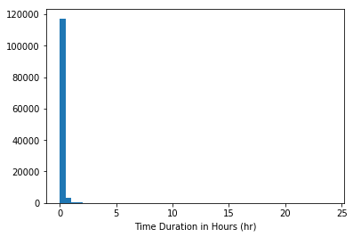

```python
bins = np.arange(0, bike_data['duration_hr'].max()+0.5, 0.5)
plt.hist(data = bike_data, x = 'duration_hr', bins = bins)
plt.xlabel('Time Duration in Hours (hr)')
plt.show()
```

> Since there plot is right-skewed, we can perform a log scale transformation to find out more information about the actual amount of hours.

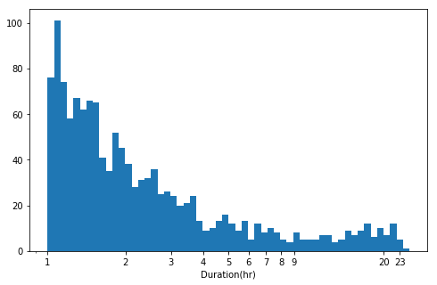

```python
# Since there plot is right-skewed, we can perform a log scale transformation
log_binsize = 0.025
bins = 10 ** np.arange(0, np.log10(bike_data['duration_hr'].max())+log_binsize, log_binsize)
plt.figure(figsize=[8, 5])
plt.hist(data = bike_data, x = 'duration_hr', bins = bins)
plt.xscale('log')
tick_locs = [1, 2, 3, 4, 5, 6, 7, 8, 9, 20, 23]
plt.xticks(tick_locs, tick_locs)
plt.xlabel('Duration(hr)')
plt.show()
```

> The histogram indicates that we a lot of users ride their bikes for small amounts of time, and we have several outliers who spend more than 4 hours in the bikes, including up to 23 hours.

```python
#Review outliers in the dataframe than are greater than 10 hours
high_outliers = (bike_data['duration_hr'] > 10)
bike_data.loc[high_outliers]
```

|  | start_time | end_time | start_station_id | start_station_name | start_station_latitude | start_station_longitude | end_station_id | end_station_name | end_station_latitude | end_station_longitude | ... | user_type | member_birth_year | member_gender | duration_min | duration_hr | day_of_week | shour | dist | member_age | member_age_bins |
| --- | --- | --- | --- | --- | --- | --- | --- | --- | --- | --- | --- | --- | --- | --- | --- | --- | --- | --- | --- | --- | --- |
| 2 | 2018-04-30 16:07:13.919 | 2018-05-01 16:02:56.7170 | 41 | Golden Gate Ave at Polk St | 37.781270 | -122.418740 | 67 | San Francisco Caltrain Station 2 (Townsend St... | 37.776639 | -122.395526 | ... | Subscriber | 1974.0 | Male | 1435.70 | 23.93 | Monday | 16 | 2.102822 | 45 | 40 - 50 |
| 3 | 2018-04-30 17:11:57.464 | 2018-05-01 12:19:16.7870 | 284 | Yerba Buena Center for the Arts (Howard St at ... | 37.784872 | -122.400876 | 115 | Jackson Playground | 37.765026 | -122.398773 | ... | Customer | 1974.0 | Female | 1147.32 | 19.12 | Monday | 17 | 2.213127 | 45 | 40 - 50 |
| 4 | 2018-04-30 18:45:21.556 | 2018-05-01 11:10:13.5410 | 196 | Grand Ave at Perkins St | 37.808894 | -122.256460 | 233 | 12th St at 4th Ave | 37.795812 | -122.255555 | ... | Customer | 1965.0 | Male | 984.85 | 16.41 | Monday | 18 | 1.455847 | 54 | 50 - 60 |
| 5 | 2018-04-30 15:39:18.353 | 2018-05-01 10:34:12.2460 | 21 | Montgomery St BART Station (Market St at 2nd St) | 37.789625 | -122.400811 | 30 | San Francisco Caltrain (Townsend St at 4th St) | 37.776598 | -122.395282 | ... | Customer | 1961.0 | Female | 1134.88 | 18.91 | Monday | 15 | 1.526942 | 58 | 50 - 60 |
| 7 | 2018-04-30 17:04:52.424 | 2018-05-01 08:34:58.7360 | 337 | Webster St at 19th St | 37.806970 | -122.266588 | 193 | Grand Ave at Santa Clara Ave | 37.812744 | -122.247215 | ... | Customer | 1990.0 | Male | 930.10 | 15.50 | Monday | 17 | 1.817857 | 29 | 20 - 30 |
| 9 | 2018-04-30 08:55:57.990 | 2018-05-01 07:13:44.7950 | 339 | Jackson St at 11th St | 37.800002 | -122.266438 | 202 | Washington St at 8th St | 37.800754 | -122.274894 | ... | Customer | 1984.0 | Male | 1337.77 | 22.30 | Monday | 8 | 0.747207 | 35 | 30 - 40 |
| 4627 | 2018-04-29 16:51:42.088 | 2018-04-30 09:27:21.3360 | 76 | McCoppin St at Valencia St | 37.771662 | -122.422423 | 122 | 19th St at Mission St | 37.760299 | -122.418892 | ... | Customer | 1995.0 | Female | 995.65 | 16.59 | Sunday | 16 | 1.300310 | 24 | 20 - 30 |
| 5209 | 2018-04-29 13:12:24.464 | 2018-04-30 08:42:30.4430 | 44 | Civic Center/UN Plaza BART Station (Market St ... | 37.781074 | -122.411738 | 52 | McAllister St at Baker St | 37.777416 | -122.441838 | ... | Customer | 1990.0 | Male | 1170.08 | 19.50 | Sunday | 13 | 2.674722 | 29 | 20 - 30 |
| 5444 | 2018-04-29 14:02:00.604 | 2018-04-30 08:23:37.1610 | 210 | 45th St at Manila | 37.833294 | -122.256224 | 176 | MacArthur BART Station | 37.828410 | -122.266315 | ... | Customer | 1986.0 | Male | 1101.60 | 18.36 | Sunday | 14 | 1.038679 | 33 | 30 - 40 |
| 5933 | 2018-04-29 17:55:57.538 | 2018-04-30 07:15:19.5550 | 259 | Addison St at Fourth St | 37.866249 | -122.299371 | 259 | Addison St at Fourth St | 37.866249 | -122.299371 | ... | Subscriber | 1998.0 | Female | 799.37 | 13.32 | Sunday | 17 | 0.000000 | 21 | 20 - 30 |
| 6059 | 2018-04-29 15:55:02.872 | 2018-04-30 06:21:24.1070 | 29 | O'Farrell St at Divisadero St | 37.782405 | -122.439446 | 3 | Powell St BART Station (Market St at 4th St) | 37.786375 | -122.404904 | ... | Subscriber | 1958.0 | Male | 866.35 | 14.44 | Sunday | 15 | 3.065515 | 61 | 60 - 70 |
| 7816 | 2018-04-28 19:33:57.949 | 2018-04-29 15:00:44.0140 | 95 | Sanchez St at 15th St | 37.766219 | -122.431060 | 147 | 29th St at Tiffany Ave | 37.744067 | -122.421472 | ... | Customer | 1989.0 | Male | 1166.77 | 19.45 | Saturday | 19 | 2.601756 | 30 | 20 - 30 |
| 8022 | 2018-04-28 18:52:20.399 | 2018-04-29 14:20:41.0990 | 45 | 5th St at Howard St | 37.781752 | -122.405127 | 121 | Mission Playground | 37.759210 | -122.421339 | ... | Customer | 1991.0 | Male | 1168.33 | 19.47 | Saturday | 18 | 2.881462 | 28 | 20 - 30 |
| 8500 | 2018-04-28 17:41:50.071 | 2018-04-29 12:34:14.6210 | 29 | O'Farrell St at Divisadero St | 37.782405 | -122.439446 | 15 | San Francisco Ferry Building (Harry Bridges Pl... | 37.795392 | -122.394203 | ... | Customer | 1977.0 | Male | 1132.40 | 18.87 | Saturday | 17 | 4.227194 | 42 | 40 - 50 |
| 8738 | 2018-04-28 21:41:09.951 | 2018-04-29 11:36:29.3030 | 308 | San Pedro Square | 37.336802 | -121.894090 | 278 | The Alameda at Bush St | 37.331932 | -121.904888 | ... | Customer | 1987.0 | Male | 835.32 | 13.92 | Saturday | 21 | 1.096866 | 32 | 30 - 40 |
| 8778 | 2018-04-28 14:53:29.588 | 2018-04-29 11:23:07.8360 | 158 | Shattuck Ave at Telegraph Ave | 37.833279 | -122.263490 | 183 | Telegraph Ave at 19th St | 37.808702 | -122.269927 | ... | Subscriber | 1984.0 | Female | 1229.63 | 20.49 | Saturday | 14 | 2.788907 | 35 | 30 - 40 |
| 10892 | 2018-04-28 02:22:03.794 | 2018-04-28 16:19:53.4810 | 107 | 17th St at Dolores St | 37.763015 | -122.426497 | 73 | Pierce St at Haight St | 37.771793 | -122.433708 | ... | Customer | 1996.0 | Male | 837.82 | 13.96 | Saturday | 2 | 1.163102 | 23 | 20 - 30 |
| 11046 | 2018-04-27 19:15:45.254 | 2018-04-28 15:47:57.9920 | 124 | 19th St at Florida St | 37.760447 | -122.410807 | 121 | Mission Playground | 37.759210 | -122.421339 | ... | Subscriber | 1976.0 | Female | 1232.20 | 20.54 | Friday | 19 | 0.935442 | 43 | 40 - 50 |
| 12709 | 2018-04-27 20:11:30.007 | 2018-04-28 08:52:50.2220 | 97 | 14th St at Mission St | 37.768265 | -122.420110 | 124 | 19th St at Florida St | 37.760447 | -122.410807 | ... | Subscriber | 1987.0 | Male | 761.33 | 12.69 | Friday | 20 | 1.192748 | 32 | 30 - 40 |
| 12802 | 2018-04-27 20:11:37.205 | 2018-04-28 07:54:35.6960 | 243 | Bancroft Way at College Ave | 37.869360 | -122.254337 | 266 | Parker St at Fulton St | 37.862464 | -122.264791 | ... | Customer | 1995.0 | Male | 702.97 | 11.72 | Friday | 20 | 1.195099 | 24 | 20 - 30 |
| 12882 | 2018-04-27 05:10:34.268 | 2018-04-28 04:05:42.3830 | 96 | Dolores St at 15th St | 37.766210 | -122.426614 | 58 | Market St at 10th St | 37.776619 | -122.417385 | ... | Customer | 1994.0 | Male | 1375.13 | 22.92 | Friday | 5 | 1.412460 | 25 | 20 - 30 |
| 15738 | 2018-04-26 18:40:14.516 | 2018-04-27 15:48:44.9830 | 109 | 17th St at Valencia St | 37.763316 | -122.421904 | 109 | 17th St at Valencia St | 37.763316 | -122.421904 | ... | Customer | 1996.0 | Female | 1268.50 | 21.14 | Thursday | 18 | 0.000000 | 23 | 20 - 30 |
| 15832 | 2018-04-26 20:24:39.238 | 2018-04-27 15:27:38.6520 | 49 | S Park St at 3rd St | 37.780760 | -122.394989 | 36 | Folsom St at 3rd St | 37.783830 | -122.398870 | ... | Customer | 1982.0 | Male | 1142.98 | 19.05 | Thursday | 20 | 0.482222 | 37 | 30 - 40 |
| 15876 | 2018-04-26 23:16:15.918 | 2018-04-27 15:18:26.1390 | 211 | Broadway at 40th St | 37.827757 | -122.256716 | 148 | Horton St at 40th St | 37.829705 | -122.287610 | ... | Customer | 1999.0 | Male | 962.17 | 16.04 | Thursday | 23 | 2.720298 | 20 | 10 - 20 |
| 21045 | 2018-04-26 01:59:13.082 | 2018-04-26 17:32:25.3300 | 109 | 17th St at Valencia St | 37.763316 | -122.421904 | 98 | Valencia St at 16th St | 37.765052 | -122.421866 | ... | Subscriber | 1964.0 | Female | 933.20 | 15.55 | Thursday | 1 | 0.192964 | 55 | 50 - 60 |
| 22920 | 2018-04-25 17:21:06.609 | 2018-04-26 10:45:24.9210 | 76 | McCoppin St at Valencia St | 37.771662 | -122.422423 | 81 | Berry St at 4th St | 37.775880 | -122.393170 | ... | Subscriber | 1978.0 | Male | 1044.30 | 17.40 | Wednesday | 17 | 2.611914 | 41 | 40 - 50 |
| 24619 | 2018-04-25 14:18:58.857 | 2018-04-26 07:43:27.5280 | 43 | San Francisco Public Library (Grove St at Hyde... | 37.778768 | -122.415929 | 70 | Central Ave at Fell St | 37.773311 | -122.444293 | ... | Customer | 1979.0 | Female | 1044.47 | 17.41 | Wednesday | 14 | 2.564024 | 40 | 30 - 40 |
| 24621 | 2018-04-25 14:03:30.195 | 2018-04-26 07:43:19.7090 | 4 | Cyril Magnin St at Ellis St | 37.785881 | -122.408915 | 70 | Central Ave at Fell St | 37.773311 | -122.444293 | ... | Customer | 1979.0 | Male | 1059.82 | 17.66 | Wednesday | 14 | 3.406749 | 40 | 30 - 40 |
| 28781 | 2018-04-24 17:46:13.742 | 2018-04-25 12:28:16.6380 | 246 | Berkeley Civic Center | 37.869060 | -122.270556 | 274 | Oregon St at Adeline St | 37.857567 | -122.267558 | ... | Customer | 1984.0 | Male | 1122.03 | 18.70 | Tuesday | 17 | 1.303924 | 35 | 30 - 40 |
| 29623 | 2018-04-24 18:55:34.554 | 2018-04-25 09:38:38.8470 | 7 | Frank H Ogawa Plaza | 37.804562 | -122.271738 | 180 | Telegraph Ave at 23rd St | 37.812678 | -122.268773 | ... | Customer | 1990.0 | Female | 883.07 | 14.72 | Tuesday | 18 | 0.938713 | 29 | 20 - 30 |
| ... | ... | ... | ... | ... | ... | ... | ... | ... | ... | ... | ... | ... | ... | ... | ... | ... | ... | ... | ... | ... | ... |
| 84892 | 2018-04-11 14:44:25.253 | 2018-04-12 12:00:03.9620 | 130 | 22nd St Caltrain Station | 37.757369 | -122.392057 | 125 | 20th St at Bryant St | 37.759200 | -122.409851 | ... | Customer | 1968.0 | Female | 1275.63 | 21.26 | Wednesday | 14 | 1.576532 | 51 | 50 - 60 |
| 86731 | 2018-04-11 17:55:37.374 | 2018-04-12 07:15:03.0090 | 66 | 3rd St at Townsend St | 37.778742 | -122.392741 | 123 | Folsom St at 19th St | 37.760594 | -122.414817 | ... | Customer | 1985.0 | Female | 799.42 | 13.32 | Wednesday | 17 | 2.797799 | 34 | 30 - 40 |
| 88910 | 2018-04-10 15:15:49.988 | 2018-04-11 13:30:46.2550 | 217 | 27th St at MLK Jr Way | 37.817015 | -122.271761 | 220 | San Pablo Ave at MLK Jr Way | 37.811351 | -122.273422 | ... | Subscriber | 1984.0 | Female | 1334.93 | 22.25 | Tuesday | 15 | 0.646067 | 35 | 30 - 40 |
| 90707 | 2018-04-10 12:30:41.248 | 2018-04-11 08:19:38.0150 | 21 | Montgomery St BART Station (Market St at 2nd St) | 37.789625 | -122.400811 | 24 | Spear St at Folsom St | 37.789677 | -122.390428 | ... | Customer | 1984.0 | Other | 1188.93 | 19.82 | Tuesday | 12 | 0.911792 | 35 | 30 - 40 |
| 91243 | 2018-04-10 18:18:40.238 | 2018-04-11 06:33:36.2180 | 77 | 11th St at Natoma St | 37.773507 | -122.416040 | 90 | Townsend St at 7th St | 37.771058 | -122.402717 | ... | Subscriber | 1986.0 | Male | 734.92 | 12.25 | Tuesday | 18 | 1.201520 | 33 | 30 - 40 |
| 92380 | 2018-04-10 07:06:09.958 | 2018-04-10 18:40:21.9380 | 21 | Montgomery St BART Station (Market St at 2nd St) | 37.789625 | -122.400811 | 37 | 2nd St at Folsom St | 37.785000 | -122.395936 | ... | Customer | 1968.0 | Male | 694.18 | 11.57 | Tuesday | 7 | 0.668990 | 51 | 50 - 60 |
| 94257 | 2018-04-10 00:51:45.053 | 2018-04-10 13:06:44.2780 | 21 | Montgomery St BART Station (Market St at 2nd St) | 37.789625 | -122.400811 | 109 | 17th St at Valencia St | 37.763316 | -122.421904 | ... | Customer | 1989.0 | Male | 734.98 | 12.25 | Tuesday | 0 | 3.461239 | 30 | 20 - 30 |
| 95503 | 2018-04-09 17:49:57.519 | 2018-04-10 08:58:25.8610 | 174 | Shattuck Ave at 51st St | 37.836801 | -122.264004 | 175 | 49th St at Telegraph Ave | 37.835946 | -122.262366 | ... | Subscriber | 1998.0 | Male | 908.47 | 15.14 | Monday | 17 | 0.172321 | 21 | 20 - 30 |
| 96279 | 2018-04-09 20:26:30.758 | 2018-04-10 07:42:53.6210 | 11 | Davis St at Jackson St | 37.797280 | -122.398436 | 13 | Commercial St at Montgomery St | 37.794231 | -122.402923 | ... | Customer | 1985.0 | Male | 676.37 | 11.27 | Monday | 20 | 0.519656 | 34 | 30 - 40 |
| 96450 | 2018-04-09 19:52:29.235 | 2018-04-10 06:57:46.2270 | 279 | Santa Clara St at 7th St | 37.339146 | -121.884105 | 279 | Santa Clara St at 7th St | 37.339146 | -121.884105 | ... | Subscriber | 1965.0 | Female | 665.27 | 11.09 | Monday | 19 | 0.000000 | 54 | 50 - 60 |
| 99737 | 2018-04-08 13:21:06.038 | 2018-04-09 12:57:17.8830 | 193 | Grand Ave at Santa Clara Ave | 37.812744 | -122.247215 | 193 | Grand Ave at Santa Clara Ave | 37.812744 | -122.247215 | ... | Customer | 1975.0 | Female | 1416.18 | 23.60 | Sunday | 13 | 0.000000 | 44 | 40 - 50 |
| 103055 | 2018-04-07 18:55:17.091 | 2018-04-08 16:24:59.5030 | 124 | 19th St at Florida St | 37.760447 | -122.410807 | 125 | 20th St at Bryant St | 37.759200 | -122.409851 | ... | Customer | 1997.0 | Female | 1289.70 | 21.50 | Saturday | 18 | 0.161982 | 22 | 20 - 30 |
| 104320 | 2018-04-07 19:24:41.885 | 2018-04-08 11:12:28.0580 | 15 | San Francisco Ferry Building (Harry Bridges Pl... | 37.795392 | -122.394203 | 22 | Howard St at Beale St | 37.789756 | -122.394643 | ... | Customer | 1991.0 | Male | 947.77 | 15.80 | Saturday | 19 | 0.627492 | 28 | 20 - 30 |
| 104567 | 2018-04-07 22:29:50.125 | 2018-04-08 08:56:44.1360 | 15 | San Francisco Ferry Building (Harry Bridges Pl... | 37.795392 | -122.394203 | 15 | San Francisco Ferry Building (Harry Bridges Pl... | 37.795392 | -122.394203 | ... | Customer | 1992.0 | Female | 626.90 | 10.45 | Saturday | 22 | 0.000000 | 27 | 20 - 30 |
| 104568 | 2018-04-07 22:13:25.462 | 2018-04-08 08:56:42.9340 | 15 | San Francisco Ferry Building (Harry Bridges Pl... | 37.795392 | -122.394203 | 15 | San Francisco Ferry Building (Harry Bridges Pl... | 37.795392 | -122.394203 | ... | Customer | 1993.0 | Female | 643.28 | 10.72 | Saturday | 22 | 0.000000 | 26 | 20 - 30 |
| 107090 | 2018-04-06 23:12:52.976 | 2018-04-07 11:07:56.6550 | 119 | 18th St at Noe St | 37.761047 | -122.432642 | 336 | Potrero Ave and Mariposa St | 37.763281 | -122.407377 | ... | Subscriber | 1981.0 | Male | 715.05 | 11.92 | Friday | 23 | 2.233337 | 38 | 30 - 40 |
| 107948 | 2018-04-05 17:15:24.581 | 2018-04-06 14:32:58.2800 | 47 | 4th St at Harrison St | 37.780955 | -122.399749 | 64 | 5th St at Brannan St | 37.776754 | -122.399018 | ... | Customer | 1971.0 | Male | 1277.55 | 21.29 | Thursday | 17 | 0.471205 | 48 | 40 - 50 |
| 108036 | 2018-04-05 17:27:20.206 | 2018-04-06 12:06:30.7460 | 160 | West Oakland BART Station | 37.805318 | -122.294837 | 235 | Union St at 10th St | 37.807239 | -122.289370 | ... | Subscriber | 1956.0 | Male | 1119.17 | 18.65 | Thursday | 17 | 0.525268 | 63 | 60 - 70 |
| 111290 | 2018-04-04 19:59:03.098 | 2018-04-05 10:27:25.1900 | 19 | Post St at Kearny St | 37.788975 | -122.403452 | 71 | Broderick St at Oak St | 37.773063 | -122.439078 | ... | Customer | 1990.0 | Male | 868.37 | 14.47 | Wednesday | 19 | 3.594036 | 29 | 20 - 30 |
| 112607 | 2018-04-04 21:29:45.810 | 2018-04-05 08:01:43.6970 | 49 | S Park St at 3rd St | 37.780760 | -122.394989 | 25 | Howard St at 2nd St | 37.787522 | -122.397405 | ... | Customer | 1993.0 | Male | 631.95 | 10.53 | Wednesday | 21 | 0.780766 | 26 | 20 - 30 |
| 113279 | 2018-04-04 10:53:08.020 | 2018-04-04 21:10:24.7510 | 59 | S Van Ness Ave at Market St | 37.774814 | -122.418954 | 323 | Broadway at Kearny | 37.798014 | -122.405950 | ... | Subscriber | 1978.0 | Male | 617.27 | 10.29 | Wednesday | 10 | 2.819677 | 41 | 40 - 50 |
| 116503 | 2018-04-03 18:16:08.286 | 2018-04-04 10:17:42.2150 | 93 | 4th St at Mission Bay Blvd S | 37.770407 | -122.391198 | 17 | Embarcadero BART Station (Beale St at Market St) | 37.792251 | -122.397086 | ... | Subscriber | 1960.0 | Male | 961.55 | 16.03 | Tuesday | 18 | 2.481840 | 59 | 50 - 60 |
| 117244 | 2018-04-03 20:52:46.519 | 2018-04-04 08:53:28.1800 | 122 | 19th St at Mission St | 37.760299 | -122.418892 | 74 | Laguna St at Hayes St | 37.776435 | -122.426244 | ... | Subscriber | 1991.0 | Male | 720.68 | 12.01 | Tuesday | 20 | 1.905855 | 28 | 20 - 30 |
| 117377 | 2018-04-03 14:52:00.137 | 2018-04-04 08:41:38.2050 | 29 | O'Farrell St at Divisadero St | 37.782405 | -122.439446 | 3 | Powell St BART Station (Market St at 4th St) | 37.786375 | -122.404904 | ... | Customer | 1983.0 | Female | 1069.63 | 17.83 | Tuesday | 14 | 3.065515 | 36 | 30 - 40 |
| 117753 | 2018-04-03 10:02:05.749 | 2018-04-04 08:06:53.4140 | 60 | 8th St at Ringold St | 37.774520 | -122.409449 | 126 | Esprit Park | 37.761634 | -122.390648 | ... | Customer | 1987.0 | Female | 1324.78 | 22.08 | Tuesday | 10 | 2.185947 | 32 | 30 - 40 |
| 117759 | 2018-04-03 14:22:35.372 | 2018-04-04 08:06:19.9100 | 3 | Powell St BART Station (Market St at 4th St) | 37.786375 | -122.404904 | 67 | San Francisco Caltrain Station 2 (Townsend St... | 37.776639 | -122.395526 | ... | Customer | 1999.0 | Male | 1063.73 | 17.73 | Tuesday | 14 | 1.359767 | 20 | 10 - 20 |
| 117956 | 2018-04-03 14:27:41.275 | 2018-04-04 07:38:34.3000 | 285 | Webster St at O'Farrell St | 37.783521 | -122.431158 | 285 | Webster St at O'Farrell St | 37.783521 | -122.431158 | ... | Customer | 1994.0 | Male | 1030.88 | 17.18 | Tuesday | 14 | 0.000000 | 25 | 20 - 30 |
| 121670 | 2018-04-03 00:13:08.185 | 2018-04-03 11:34:40.7280 | 119 | 18th St at Noe St | 37.761047 | -122.432642 | 134 | Valencia St at 24th St | 37.752428 | -122.420628 | ... | Customer | 1990.0 | Female | 681.53 | 11.36 | Tuesday | 0 | 1.425315 | 29 | 20 - 30 |
| 122891 | 2018-04-02 17:29:52.377 | 2018-04-03 08:38:44.3170 | 60 | 8th St at Ringold St | 37.774520 | -122.409449 | 125 | 20th St at Bryant St | 37.759200 | -122.409851 | ... | Subscriber | 1980.0 | Other | 908.85 | 15.15 | Monday | 17 | 1.702791 | 39 | 30 - 40 |
| 127070 | 2018-04-01 19:35:24.108 | 2018-04-02 11:07:54.7240 | 200 | 2nd Ave at E 18th St | 37.800214 | -122.253810 | 200 | 2nd Ave at E 18th St | 37.800214 | -122.253810 | ... | Customer | 1986.0 | Male | 932.50 | 15.54 | Sunday | 19 | 0.000000 | 33 | 30 - 40 |

111 rows × 21 columns

### Exploring the Time Spent on the Bike in Minutes

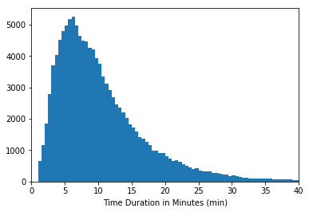

```python
bins = np.arange(0, bike_data['duration_min'].max()+0.5, 0.5)
plt.hist(data = bike_data, x = 'duration_min', bins = bins)
plt.xlabel('Time Duration in Minutes (min)')
plt.xlim([0,40])
plt.show()
```

> The histogram of time spent on the bike in minutes is right-skewed, just like the previous exploration on duration_hr. It is not surprising since the bike service charges every 30 minutes that most people use it for small amounts of time. The following question would be to understand which user_type (customer or subscriber) is spending most of the time on the bikes.

### Exploring Days of the Week Where Bikes Are Mostly Used

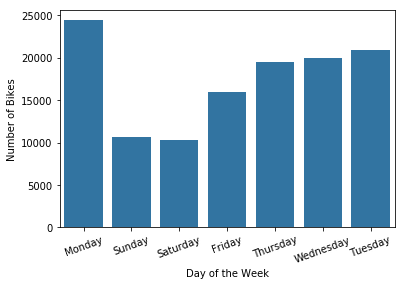

```python
base_color = sb.color_palette()[0]
sb.countplot(data = bike_data, x ='day_of_week', color = base_color);
plt.xticks(rotation = 20);
plt.ylabel('Number of Bikes')
plt.xlabel('Day of the Week');
```

> This plot suggests that Mondays is the day of the week where users mostly ride their bikes. The next question that I'm wondering is about the average distance that riders go through everyday of the week.

### Exploring the variable user_type

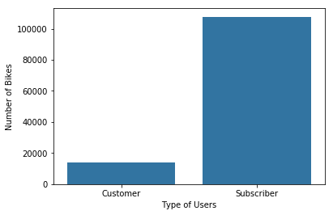

```python
sb.countplot(data=bike_data,x='user_type', color = base_color)
plt.ylabel('Number of Bikes')
plt.xlabel('Type of Users');
```

> The plot seems to suggest that the majority of users are subscribers of the bike service.

### Exploring the variable distance

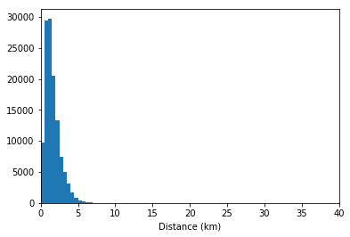

```python
bins = np.arange(0, bike_data['dist'].max()+0.5, 0.5)
plt.hist(data = bike_data, x = 'dist', bins = bins)
plt.xlabel('Distance (km)')
plt.xlim([0,40])
plt.show()
```

> The histogram is right-skewed and it seems to suggest that most of the trips have a short distance. There is a great quantity of values that seem to have zero km or "circular trips" (trips start and end at the same station). So, I'm going to remove them since this data is irrelevant and safe to drop from the model.

```python
bike_data = bike_data.drop(bike_data.index[(bike_data['dist'] == 0)])
```

```python
#Reviews that the rows were succesfully dropped
bike_data.query('dist == 0')
```

|  | start_time | end_time | start_station_id | start_station_name | start_station_latitude | start_station_longitude | end_station_id | end_station_name | end_station_latitude | end_station_longitude | ... | user_type | member_birth_year | member_gender | duration_min | duration_hr | day_of_week | shour | dist | member_age | member_age_bins |
| --- | --- | --- | --- | --- | --- | --- | --- | --- | --- | --- | --- | --- | --- | --- | --- | --- | --- | --- | --- | --- | --- |

0 rows × 21 columns

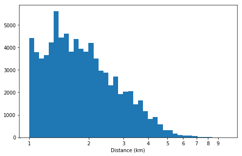

```python
# Since there plot is right-skewed, we can perform a log scale transformation
log_binsize = 0.025
bins = 10 ** np.arange(0, np.log10(bike_data['dist'].max())+log_binsize, log_binsize)
plt.figure(figsize=[8, 5])
plt.hist(data = bike_data, x = 'dist', bins = bins)
plt.xscale('log')
tick_locs = [1, 2, 3, 4, 5, 6, 7, 8, 9]
plt.xticks(tick_locs, tick_locs)
plt.xlabel('Distance (km)')
plt.show()
```

> Again, it is not surprising that since users ride their bikes for pretty much short periods of time, the majority of distances are also quite short.

### Discuss the distribution(s) of your variable(s) of interest. Were there any unusual points? Did you need to perform any transformations?

> There are pretty unusual points in the Duration due to the fact that several people have used the bicyles for more than 10 hours a day. Even though, the majority of users ride their bikes for pretty much short distances.

### Of the features you investigated, were there any unusual distributions? Did you perform any operations on the data to tidy, adjust, or change the form of the data? If so, why did you do this?

> I did perform several operations to the data in order to find our information related to the duration in hours and minutes, age groups of the users and distance. I did it in order to investigate better which variables are the most important factors on the dataset.

## Bivariate Exploration

> First, I'm going to look at the pairwise correlations present between features in the data.

```python
# Categorize the variables between numeric and categoric
numeric_vars = ['duration_hr','member_age', 'dist']
categoric_vars = ['day_of_week', 'member_age_bins']
```

```python
# Create list of days of the week and age group and organizes them by the correct order
week = ['Monday', 'Tuesday', 'Wednesday', 'Thursday', 'Friday', 'Saturday', 'Sunday']
agroups = ['10 - 20', '20 - 30', '30 - 40', '40 - 50', '50 - 60', '60 - 70', '70 - 80', '80 - 90', '90 - 99']
```

```python
# Order variables "day_of_week" and "member_age_bins" by list created beforehand
pd_ver = pd.__version__.split('.')
if (int(pd_ver[0]) > 0) or (int(pd_ver[1]) >= 21):#V.021 or later
    days_week = pd.api.types.CategoricalDtype(ordered = True, categories = week)
    bike_data["day_of_week"] = bike_data["day_of_week"].astype(days_week)
    age_groups = pd.api.types.CategoricalDtype(ordered = True, categories = agroups)
    bike_data["member_age_bins"] = bike_data["member_age_bins"].astype(age_groups)
else: #pre V0.21
    bike_data["day_of_week"] = bike_data["day_of_week"].astype('category', ordered = True, categories = week)
    bike_data["member_age_bins"] = bike_data["member_age_bins"].astype('category', ordered = True, categories = agroups)
```

### Understanding the relation between various numeric variables

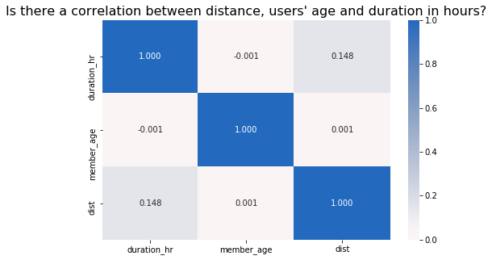

```python
# correlation plot
plt.figure(figsize = [8, 5])
ax = sb.heatmap(bike_data[numeric_vars].corr(), annot = True, fmt = '.3f',
           cmap = 'vlag_r', center = 0)
ax.set_title("Is there a correlation between distance, users' age and duration in hours?", fontsize=16)
plt.show()
```

### What type of user has the longest rides?

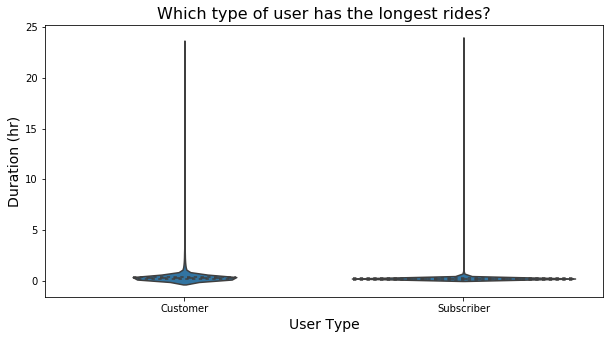

```python
plt.figure (figsize = [10,5])
ax1 = sb.violinplot(data = bike_data, y = 'duration_hr', x= 'user_type', color = base_color,
               height = 10, aspect = 1.5, inner = 'quartile')
ax1.set_title("Which type of user has the longest rides?", fontsize=16)
ax1.set_xlabel("User Type", fontsize= 14)
ax1.set_ylabel("Duration (hr)", fontsize= 14)
plt.show();
```

> The plot suggests that the majority of subscribers use the bike service for a small amount of type. However, both type of users seem to have outliers who have use the bikes for more than 3 hours.

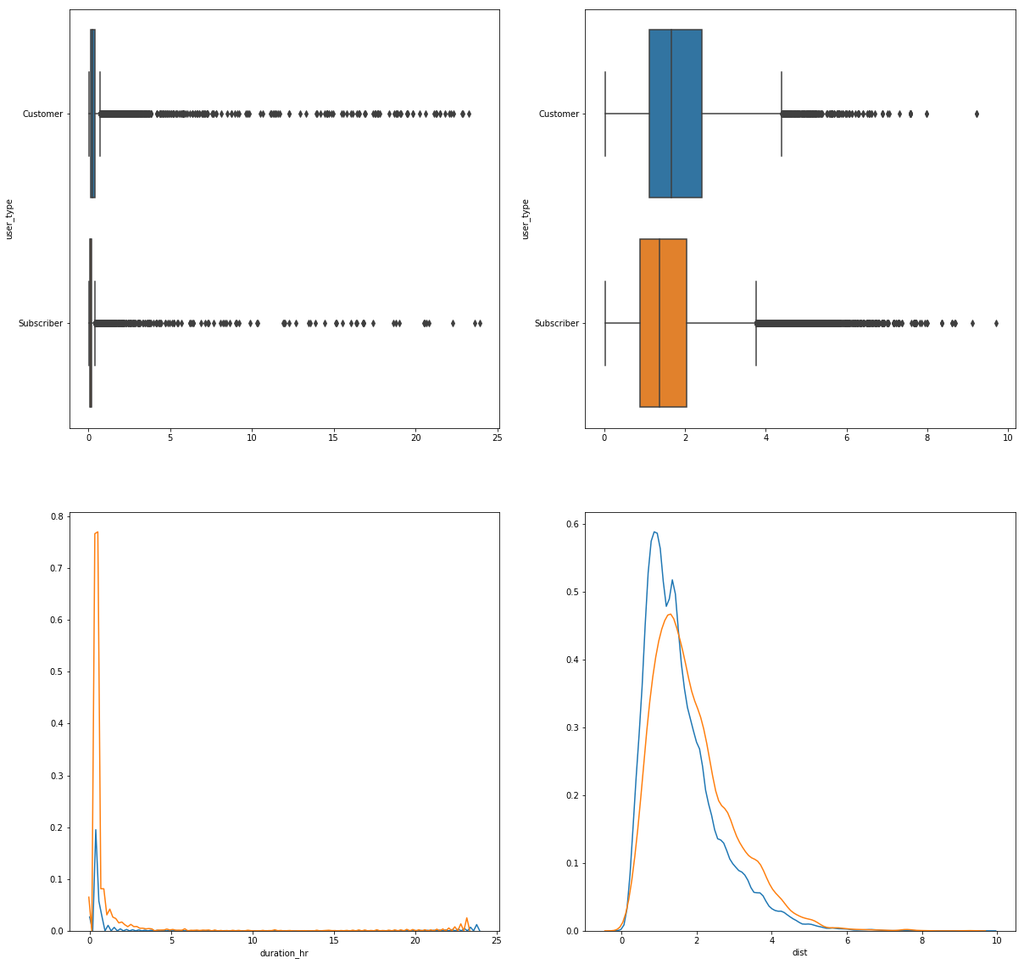

```python
#Plot to visualize the distribution of trip duration and distance by user type
fig, (ax2, ax3) = plt.subplots(2, 2, figsize=(20, 20))
for i, col in enumerate(['duration_hr', 'dist']):
    for k, user in enumerate(bike_data['user_type'].unique()):
        sb.distplot(bike_data[bike_data['user_type']==user][col], hist=False, ax=ax3[i])
    # Graph the boxplots
    sb.boxplot(x=col, y='user_type', data=bike_data, ax=ax2[i])
    ax2[i].set_xlabel('')
```

> The plots suggest that while both groups generally travel within similar distances, subscribers of the Lyft bike service arrive to their destinations faster than casual riders.

### Understanding the relation between categorical features

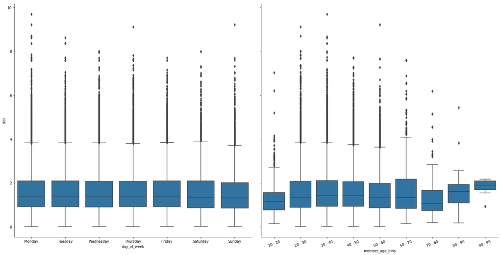

```python
# plot matrix of distance against categorical features.
samples = np.random.choice(bike_data.shape[0], 500, replace = False)
bike_data_samp = bike_data.reindex()

def boxgrid(x, y, **kwargs):
    """ Quick hack for creating box plots with seaborn's PairGrid. """
    default_color = sb.color_palette()[0]
    sb.boxplot(x, y, color = default_color)

plt.figure(figsize = [20, 10])
ax4 = sb.PairGrid(data = bike_data_samp, y_vars = ['dist'], x_vars = categoric_vars,
                height = 10, aspect = 1);
ax4.map(boxgrid)
plt.xticks(rotation = 20)
plt.show();
```

### Understanding when are the longest rides during the week in minutes

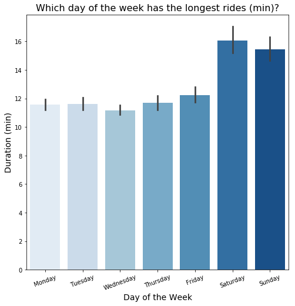

```python
plt.figure(figsize = [8, 8])
ax6 = sb.barplot(data = bike_data, x = 'day_of_week', y = 'duration_min', palette = 'Blues')
plt.xticks(rotation=20)
ax6.set_title("Which day of the week has the longest rides (min)?", fontsize=16)
ax6.set_xlabel("Day of the Week", fontsize= 14)
ax6.set_ylabel("Duration (min)", fontsize= 14)
plt.show()
```

> Unsurprisingly, users ride their bikes longer during the weekends than any other day of the week.

### Understanding which hour of the day is the most popular among riders

```python
trip_hour = bike_data.groupby('shour').agg({'bike_id':'count'}).reset_index()
trip_hour['bike_id'] = (trip_hour['bike_id']/trip_hour['bike_id'].sum())*100
```

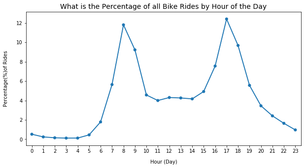

```python
plt.figure(figsize=(10,5))
sb.pointplot(x='shour', y='bike_id', scale=.7, color=base_color, data=trip_hour)
plt.title('What is the Percentage of all Bike Rides by Hour of the Day', fontsize=14)
plt.xlabel('Hour (Day)', labelpad=12)
plt.ylabel('Percentage(%)of Rides', labelpad=16);
```

### Talk about some of the relationships you observed in this part of the investigation. How did the feature(s) of interest vary with other features in the dataset?

> Also, the observed data suggests that the majority of suscribers use their bikes for pretty small periods of time, and not for long rides. Although both groups have outliers of more than 3 hours.

### Did you observe any interesting relationships between the other features (not the main feature(s) of interest)?

> One intersting relationship is the fact that it seems that suscribers of the ride share service seem to arrive to their destinations faster than casual users, eventhough both groups travel similar distances.

## Multivariate Exploration

```python
#Creates new dataframe with suscribers information group by starting hour and member_age_bins
subscriber_age = bike_data[bike_data['user_type']=='Subscriber'].groupby(['shour', 'member_age_bins']).agg({'bike_id':'count'}).reset_index()
```

```python
subscriber_age.bike_id.nunique()
```

```
131
```

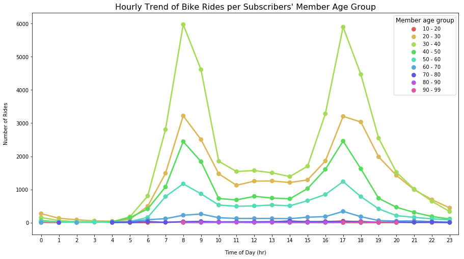

```python
base_color = sb.color_palette("hls", 9)
plt.figure(figsize=(15,8))
ax = sb.pointplot(x='shour', y='bike_id', hue='member_age_bins', data=subscriber_age, palette = base_color)
plt.title("Hourly Trend of Bike Rides per Subscribers' Member Age Group", fontsize=16)
plt.xlabel('Time of Day (hr)', labelpad=14)
plt.ylabel('Number of Rides', labelpad=14)
leg = ax.legend()
leg.set_title('Member age group',prop={'size':12})
```

```python
customer_age = bike_data[bike_data['user_type']=='Customer'].groupby(['shour', 'member_age_bins']).agg({'bike_id':'count'}).reset_index()
customer_age.bike_id.nunique()
```

```
84
```

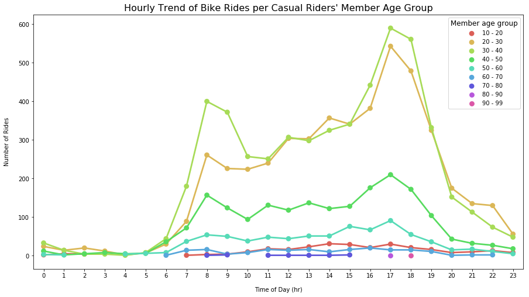

```python
base_color = sb.color_palette("hls", 9)
plt.figure(figsize=(15,8))
ax = sb.pointplot(x='shour', y='bike_id', hue='member_age_bins', data=customer_age , palette = base_color)
plt.title("Hourly Trend of Bike Rides per Casual Riders' Member Age Group", fontsize=16)
plt.xlabel('Time of Day (hr)', labelpad=14)
plt.ylabel('Number of Rides', labelpad=14)
leg = ax.legend()
leg.set_title('Member age group',prop={'size':12})
```

```python
def log_trans(x, inverse = False):
    """ quick function for computing log and power operations """
    if not inverse:
        return np.log10(x)
    else:
        return np.power(10, x)

bike_data['log_dist'] = bike_data['dist'].apply(log_trans)
bike_data['log_duration_hr'] = bike_data['duration_hr'].apply(log_trans)
```

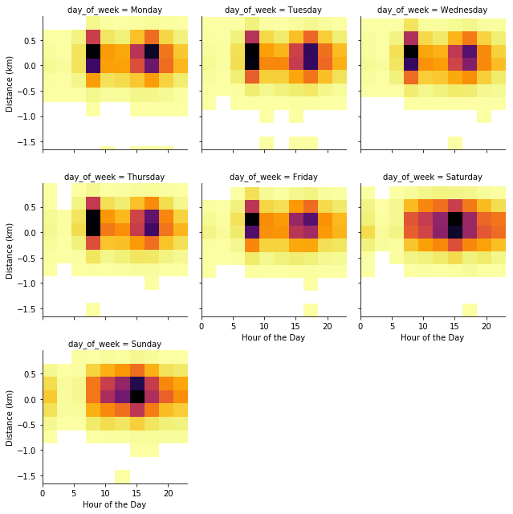

```python
# create faceted heat maps on day of the week by time of the day and log_distance(km)
g = sb.FacetGrid(data = bike_data, col = 'day_of_week', col_wrap = 3, height = 3)
g.map(hist2dgrid, 'shour', 'log_dist', color = 'inferno_r')
g.set_xlabels('Hour of the Day')
g.set_ylabels('Distance (km)')
plt.show()
```

> It seems that for the most part, users ride their backs for pretty small distances. From Monday to Friday, the most popular hour is in the mornings. However, during the weekend, the most popular hour to ride the bikes is around 3pm.

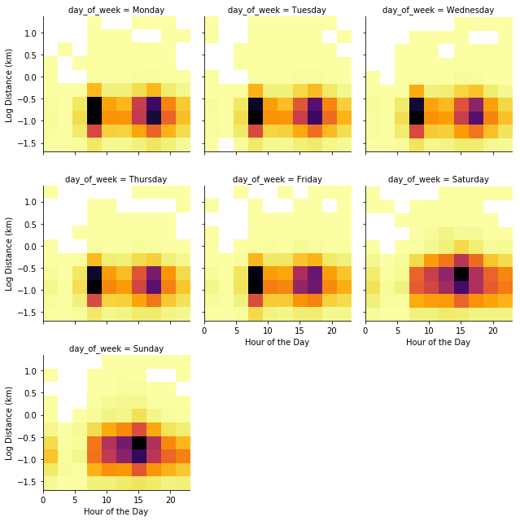

```python
# create faceted heat maps on day of the week by time of the day and log_duration(hr)
g = sb.FacetGrid(data = bike_data, col = 'day_of_week', col_wrap = 3, height = 3)
g.map(hist2dgrid, 'shour', 'log_duration_hr', color = 'inferno_r')
g.set_xlabels('Hour of the Day')
g.set_ylabels('Log Distance (km)')
plt.show()
```

> Since users ride their bikes mostly during short periods of time, it comes as no surprise that the distances are quite short as well. Similar patterns to the ones observed in the previous plots show over here: Riders frequently use bikes during commute hours during weekdays. On weekends, the most popular hour to ride bikes is around 3pm.

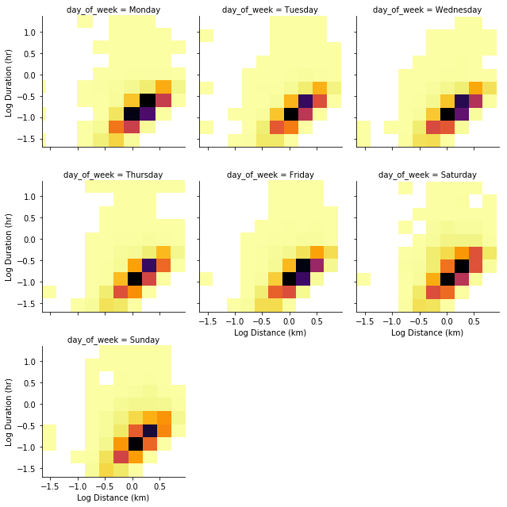

```python
# create faceted heat maps on day of the week by log_distance(km) and log_duration(km)
g = sb.FacetGrid(data = bike_data, col = 'day_of_week', col_wrap = 3, height = 3)
g.map(hist2dgrid, 'log_dist', 'log_duration_hr', color = 'inferno_r')
g.set_xlabels('Log Distance (km)')
g.set_ylabels('Log Duration (hr)')
plt.show()
```

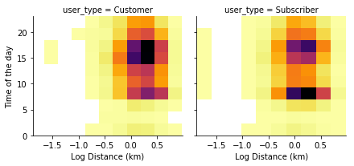

```python
# create faceted heat maps on day of the week by log_distance(km) and log_duration(km)
g = sb.FacetGrid(data = bike_data, col = 'user_type', col_wrap = 3, height = 3)
g.map(hist2dgrid, 'log_dist', 'shour', color = 'inferno_r')
g.set_xlabels('Log Distance (km)')
g.set_ylabels('Time of the day')
plt.show()
```

> The visualizations suggest that the user_type "Customer" is the one who is riding their bikes for the longest period of time but during the afternoons while "Subcribers" are using the bike service to ride equally short distances but during the mornings.

### Were there any interesting or surprising interactions between features?

> Although I thought that weekends were a "favorite", I found very interesting that riders prefer Mondays too to use the bike service.